# Project@DataMining

May 10, 2019

Setting the seed to ‘12345’ for rerunning and loading all required libraries.

```r
set.seed(12345)

library(leaps)
library(MASS)
library(ROCR)
```

```r
library(ggplot2)
library(e1071)
df <- read.csv("C:/Users/Kowshik/Desktop/Project@DM/Fundraising.csv",header = T)
test.df<-read.csv("C:/Users/Kowshik/Desktop/Project@DM/FutureFundraising.csv",header = T)
dim(test.df)
```

```
## [1] 2000   24
```

```r
head(df)
```

```
##   Row.Id Row.Id. zipconvert_2 zipconvert_3 zipconvert_4 zipconvert_5
## 1      1      17            0            1            0            0
## 2      2      25            1            0            0            0
## 3      3      29            0            0            0            1
## 4      4      38            0            0            0            1
## 5      5      40            0            1            0            0
## 6      6      53            0            1            0            0
##   homeowner.dummy NUMCHLD INCOME gender.dummy WEALTH   HV Icmed Icavg IC15
## 1               1       1      5            1      9 1399   637   703    1
## 2               1       1      1            0      7  698   422   463    4
## 3               0       2      5            1      8  828   358   376   13
## 4               1       1      3            0      4 1471   484   546    4
## 5               1       1      4            0      8  547   386   432    7
## 6               1       1      4            1      8  482   242   275   28
##   NUMPROM RAMNTALL MAXRAMNT LASTGIFT totalmonths TIMELAG  AVGGIFT TARGET_B
## 1      74      102        6        5          29       3 4.857143        1
## 2      46       94       12       12          34       6 9.400000        1
## 3      32       30       10        5          29       7 4.285714        1
## 4      94      177       10        8          30       3 7.080000        0
## 5      20       23       11       11          30       6 7.666667        0
## 6      38       73       10       10          31       3 7.300000        1
##   TARGET_D
## 1        5
## 2       10
## 3        5
## 4        0
## 5        0
## 6        8
```

```r
## STEP #0: Deleting unnecessary columns from our data.

df$Row.Id  <- NULL
df$Row.Id. <- NULL
df$TARGET_D <- NULL
```

The “Fundraising.csv” dataset was partitioned into 60% training and 40% validation sets. We deleted the Row Id, Row Id., and TARGET_D columns from the dataset.

In this particular case, responders to the fundraising drive is the rarer class and more important than the non-responders. Such an asymmetric response and cost requires oversampling the donor class to obtain more useful data for improving the performance of the classifiers.

Since the response rate is 5.1%, a simple random sampling from the original dataset would have yielded too few relevant classes to build a strong predictive model. Therefore, a stratified sampling with a disproportionate weighting of the donor class is used for the training data.

We have used logistic regression to build our first model.

```r
## STEP #1: Partitioning our dataset. (60% Training, 40% Validation).

train.rows <- sample(rownames(df), dim(df)[1]*0.6)
train.df <- df[train.rows, ]

valid.rows <- setdiff(rownames(df), train.rows)
valid.df <- df[valid.rows, ]
```

```r
# Full Model.
full.model <- glm(TARGET_B ~ ., data = train.df, family = "binomial")
summary(full.model)
```

```
##
## Call:
## glm(formula = TARGET_B ~ ., family = "binomial", data = train.df)
##
## Deviance Residuals:
##    Min      1Q  Median      3Q     Max
## -1.791  -1.155  -0.729   1.154   2.119
##
## Coefficients:
##                   Estimate Std. Error z value Pr(>|z|)
## (Intercept)     -1.209e+01  3.078e+02  -0.039   0.9687
## zipconvert_2     1.363e+01  3.078e+02   0.044   0.9647
## zipconvert_3     1.358e+01  3.078e+02   0.044   0.9648
## zipconvert_4     1.344e+01  3.078e+02   0.044   0.9652
## zipconvert_5     1.358e+01  3.078e+02   0.044   0.9648
## homeowner.dummy  7.723e-02  1.192e-01   0.648   0.5171
## NUMCHLD         -2.857e-01  1.376e-01  -2.076   0.0379 *
## INCOME           7.943e-02  3.275e-02   2.425   0.0153 *
## gender.dummy     7.535e-02  9.755e-02   0.772   0.4399
## WEALTH           1.666e-02  2.259e-02   0.738   0.4608
## HV               1.200e-04  8.892e-05   1.350   0.1770
## Icmed            6.484e-04  1.172e-03   0.553   0.5800
## Icavg           -1.034e-03  1.274e-03  -0.812   0.4170
## IC15             2.534e-03  5.606e-03   0.452   0.6512
## NUMPROM          5.047e-03  3.340e-03   1.511   0.1308
## RAMNTALL        -3.396e-04  6.884e-04  -0.493   0.6218
## MAXRAMNT         4.709e-03  8.131e-03   0.579   0.5625
## LASTGIFT        -2.272e-02  1.113e-02  -2.041   0.0412 *
## totalmonths     -5.668e-02  1.289e-02  -4.398 1.09e-05 ***
## TIMELAG          5.986e-03  8.768e-03   0.683   0.4948
## AVGGIFT          6.386e-03  1.565e-02   0.408   0.6833
## ---
## Signif. codes:  0 '***' 0.001 '**' 0.01 '*' 0.05 '.' 0.1 ' ' 1
##
## (Dispersion parameter for binomial family taken to be 1)
##
##     Null deviance: 2595.1  on 1871  degrees of freedom
## Residual deviance: 2526.2  on 1851  degrees of freedom
## AIC: 2568.2
##
## Number of Fisher Scoring iterations: 12
```

```r
# Model after AIC method.
step.model <- stepAIC(full.model, direction = "both", trace = TRUE)
```

```
## Start:  AIC=2568.18
## TARGET_B ~ zipconvert_2 + zipconvert_3 + zipconvert_4 + zipconvert_5 +
##     homeowner.dummy + NUMCHLD + INCOME + gender.dummy + WEALTH +
##     HV + Icmed + Icavg + IC15 + NUMPROM + RAMNTALL + MAXRAMNT +
##     LASTGIFT + totalmonths + TIMELAG + AVGGIFT
##
##                   Df Deviance    AIC
## - AVGGIFT          1   2526.3 2566.3
## - IC15             1   2526.4 2566.4
## - RAMNTALL         1   2526.4 2566.4
## - Icmed            1   2526.5 2566.5
## - homeowner.dummy  1   2526.6 2566.6
## - TIMELAG          1   2526.7 2566.7
## - WEALTH           1   2526.7 2566.7
## - gender.dummy     1   2526.8 2566.8
## - Icavg            1   2526.8 2566.8
## - MAXRAMNT         1   2527.1 2567.1
## - HV               1   2528.0 2568.0
## <none>                 2526.2 2568.2
## - NUMPROM          1   2528.4 2568.4
## - zipconvert_4     1   2529.9 2569.9
## - zipconvert_3     1   2530.3 2570.3
## - zipconvert_5     1   2530.3 2570.3
## - zipconvert_2     1   2530.5 2570.5
## - NUMCHLD          1   2530.7 2570.7
## - LASTGIFT         1   2530.9 2570.9
## - INCOME           1   2532.1 2572.1
## - totalmonths      1   2546.0 2586.0
##
## Step:  AIC=2566.35
## TARGET_B ~ zipconvert_2 + zipconvert_3 + zipconvert_4 + zipconvert_5 +
##     homeowner.dummy + NUMCHLD + INCOME + gender.dummy + WEALTH +
##     HV + Icmed + Icavg + IC15 + NUMPROM + RAMNTALL + MAXRAMNT +
##     LASTGIFT + totalmonths + TIMELAG
##
##                   Df Deviance    AIC
## - IC15             1   2526.6 2564.6
## - RAMNTALL         1   2526.6 2564.6
## - Icmed            1   2526.7 2564.7
## - homeowner.dummy  1   2526.8 2564.8
```

[output cut: 282 more lines]

```
## + WEALTH           1   2532.0 2554.0
## + TIMELAG          1   2532.1 2554.1
## + homeowner.dummy  1   2532.1 2554.1
## - zipconvert_4     1   2536.2 2554.2
## + IC15             1   2532.3 2554.3
## + Icmed            1   2532.4 2554.4
## + Icavg            1   2532.5 2554.5
## + RAMNTALL         1   2532.5 2554.5
## - zipconvert_3     1   2536.5 2554.5
## - zipconvert_2     1   2536.7 2554.7
## - zipconvert_5     1   2536.8 2554.8
## - NUMCHLD          1   2537.4 2555.4
## - INCOME           1   2541.6 2559.6
## - LASTGIFT         1   2541.9 2559.9
## - totalmonths      1   2553.7 2571.7
```

```r
summary(step.model)
```

```
##
## Call:
## glm(formula = TARGET_B ~ zipconvert_2 + zipconvert_3 + zipconvert_4 +
##     zipconvert_5 + NUMCHLD + INCOME + NUMPROM + LASTGIFT + totalmonths,
##     family = "binomial", data = train.df)
##
## Deviance Residuals:
##     Min       1Q   Median       3Q      Max
## -1.7812  -1.1540  -0.7153   1.1576   2.1421
##
## Coefficients:
##                Estimate Std. Error z value Pr(>|z|)
## (Intercept)  -11.761568 307.737684  -0.038  0.96951
## zipconvert_2  13.593103 307.737401   0.044  0.96477
## zipconvert_3  13.522039 307.737403   0.044  0.96495
## zipconvert_4  13.392447 307.737402   0.044  0.96529
## zipconvert_5  13.607053 307.737394   0.044  0.96473
## NUMCHLD       -0.297271   0.137124  -2.168  0.03017 *
## INCOME         0.087460   0.029111   3.004  0.00266 **
## NUMPROM        0.003623   0.002232   1.623  0.10460
## LASTGIFT      -0.014464   0.005023  -2.879  0.00399 **
## totalmonths   -0.057495   0.012667  -4.539 5.65e-06 ***
## ---
## Signif. codes:  0 '***' 0.001 '**' 0.01 '*' 0.05 '.' 0.1 ' ' 1
##
## (Dispersion parameter for binomial family taken to be 1)
##
##     Null deviance: 2595.1  on 1871  degrees of freedom
## Residual deviance: 2532.5  on 1862  degrees of freedom
## AIC: 2552.5
##
## Number of Fisher Scoring iterations: 12
```

```r
# Reduced model (after dropping "zipconvert_2", "zipconvert_3", "zipconvert_4", "zipconvert_5" due to extremely high p-values).
reduced.model <- glm(TARGET_B ~ NUMCHLD + INCOME + NUMPROM + LASTGIFT + totalmonths, data = train.df, family = "binomial")
summary(reduced.model)
```

```
##
## Call:
## glm(formula = TARGET_B ~ NUMCHLD + INCOME + NUMPROM + LASTGIFT +
##     totalmonths, family = "binomial", data = train.df)
##
## Deviance Residuals:
##     Min       1Q   Median       3Q      Max
## -1.7564  -1.1503  -0.8066   1.1536   2.1297
##
## Coefficients:
##              Estimate Std. Error z value Pr(>|z|)
## (Intercept)  1.754357   0.468652   3.743 0.000182 ***
## NUMCHLD     -0.300244   0.136652  -2.197 0.028010 *
## INCOME       0.090875   0.028901   3.144 0.001665 **
## NUMPROM      0.003661   0.002227   1.644 0.100187
## LASTGIFT    -0.013988   0.004993  -2.801 0.005089 **
## totalmonths -0.057288   0.012636  -4.534  5.8e-06 ***
## ---
## Signif. codes:  0 '***' 0.001 '**' 0.01 '*' 0.05 '.' 0.1 ' ' 1
##
## (Dispersion parameter for binomial family taken to be 1)
##
##     Null deviance: 2595.1  on 1871  degrees of freedom
## Residual deviance: 2539.7  on 1866  degrees of freedom
## AIC: 2551.7
##
## Number of Fisher Scoring iterations: 4
```

```r
# Further reduced model/final model (after dropping "NUMPROM" due to p-value > 10%).
final.model <- glm(TARGET_B ~ NUMCHLD + INCOME + LASTGIFT + totalmonths, data = train.df, family = "binomial")
summary(final.model)
```

```
##
## Call:
## glm(formula = TARGET_B ~ NUMCHLD + INCOME + LASTGIFT + totalmonths,
##     family = "binomial", data = train.df)
##
## Deviance Residuals:
##     Min       1Q   Median       3Q      Max
## -1.7463  -1.1564  -0.7973   1.1549   2.1049
##
## Coefficients:
##              Estimate Std. Error z value Pr(>|z|)
## (Intercept)  2.129783   0.409223   5.204 1.95e-07 ***
## NUMCHLD     -0.326439   0.135797  -2.404  0.01622 *
## INCOME       0.090185   0.028869   3.124  0.00178 **
## LASTGIFT    -0.014034   0.004995  -2.810  0.00496 **
## totalmonths -0.062658   0.012174  -5.147 2.65e-07 ***
## ---
## Signif. codes:  0 '***' 0.001 '**' 0.01 '*' 0.05 '.' 0.1 ' ' 1
##
## (Dispersion parameter for binomial family taken to be 1)
##
##     Null deviance: 2595.1  on 1871  degrees of freedom
## Residual deviance: 2542.4  on 1867  degrees of freedom
## AIC: 2552.4
##
## Number of Fisher Scoring iterations: 4
```

```r
reduced.df<-df[,c(6,7,17)]
head(reduced.df)
```

```
##   NUMCHLD INCOME LASTGIFT
## 1       1      5        5
## 2       1      1       12
## 3       2      5        5
## 4       1      3        8
## 5       1      4       11
## 6       1      4       10
```

A logistic regression analysis was conducted using all the predictor variables initially on the training set. The model was further refined by using stepwise regression to eliminate predictors that were not significant. The predictors for our final model include NUMCHLD, INCOME, LASTGIFT, and totalmonths.

We used Excel to calculate the optimum cutoff value for the model. A value of 0.498 resulted in the maximum profit and minimum cost. Therefore 0.5 was set as the cutoff for classifying the entries in the model.

```r
predict_valid <- predict(final.model, valid.df, type = "response")
table(valid.df$TARGET_B,predict_valid>0.5)
```

```
##
##     FALSE TRUE
##   0   332  286
##   1   272  358
```

```r
#Profit from the validation data
Profit_valid<-(358*((13-0.68)/9.8))
Profit_valid
```

```
## [1] 450.0571
```

```r
#cost from the validation data
cost_valid<-(272*((0-0.68)/0.53))
cost_valid
```

```
## [1] -348.9811
```

For the first model, net profit for validation data = $450.0571 - $348.9811 = $101.076

```r
predict_train <- predict(final.model, train.df, type = "response")
table(train.df$TARGET_B,predict_train>0.5)
```

```
##
##     FALSE TRUE
##   0   534  408
##   1   397  533
```

```r
#Profit from the training data
Profit_valid<-(533*((13-0.68)/9.8))
Profit_valid
```

```
## [1] 670.0571
```

```r
#cost from the training data
cost_valid<-(397*((0-0.68)/0.53))
cost_valid
```

```
## [1] -509.3585
```

Net profit for the training data = $670.0571 - $509.3585 = $160.6986

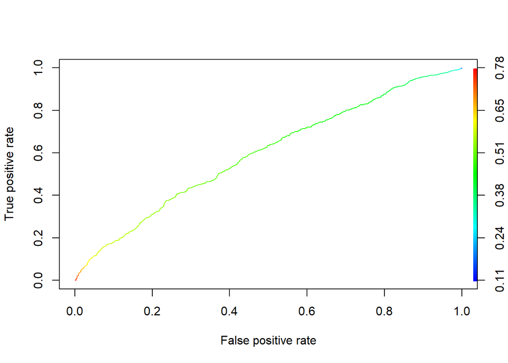

```r
#ROCR Curve

ROCRpred <- prediction(predict_train, train.df$TARGET_B)
ROCRperf <- performance(ROCRpred, 'tpr','fpr')
plot(ROCRperf, colorize = TRUE, text.adj = c(-0.2,1.7))
```

The above Roc plot is for the training dataset

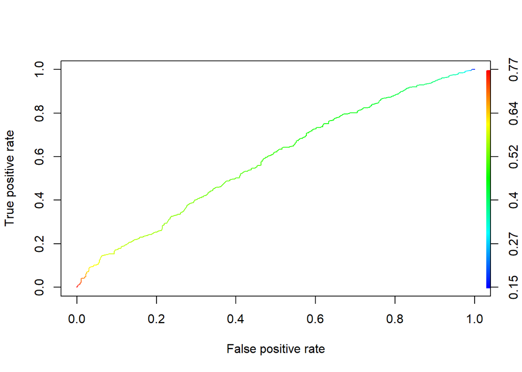

```r
ROCRpred <- prediction(predict_valid, valid.df$TARGET_B)
ROCRperf <- performance(ROCRpred, 'tpr','fpr')
plot(ROCRperf, colorize = TRUE, text.adj = c(-0.2,1.7))
```

The above ROC plot is for the validation dataset. The ROC curve gives a better indication of the model performance in cases where asymmetric costs are involved by plotting the sensitivity over specificity. The closer the curve gets to the top-left corner, the better is the performance. In this case, the ROC curve signifies a slightly better performance than the naive rule which would have yielded a diagonal.

The model was run on the FutureFundraising dataset to classify the entries.

```r
predict_test <- predict(final.model, test.df, type = "response")
test_TARGET_B <- ifelse(predict_test>0.5,1,0)
test_TARGET_B
```

```
##    1    2    3    4    5    6    7    8    9   10   11   12   13   14   15
##    1    0    0    0    1    1    0    0    1    0    0    0    0    0    1
##   16   17   18   19   20   21   22   23   24   25   26   27   28   29   30
##    0    1    0    0    0    1    0    0    0    1    1    0    0    1    0
##   31   32   33   34   35   36   37   38   39   40   41   42   43   44   45
##    0    1    0    1    0    1    0    0    0    0    0    1    0    1    1
##   46   47   48   49   50   51   52   53   54   55   56   57   58   59   60
##    0    1    0    0    1    1    0    0    0    0    1    0    0    0    1
##   61   62   63   64   65   66   67   68   69   70   71   72   73   74   75
##    0    0    0    0    0    0    0    0    1    0    1    1    0    0    0
##   76   77   78   79   80   81   82   83   84   85   86   87   88   89   90
##    1    1    0    0    1    1    0    0    0    0    0    0    0    0    1
##   91   92   93   94   95   96   97   98   99  100  101  102  103  104  105
##    0    0    0    0    1    1    0    0    1    1    1    0    1    1    1
##  106  107  108  109  110  111  112  113  114  115  116  117  118  119  120
```

[output cut: 253 more lines]

The probabilities of the entries in FutureFundraising dataset has been sorted in descending order.

```r
pred_test <- predict(final.model, newdata = test.df, type = "response")
fund.pred <- pred_test[order(-pred_test)]
fund.pred
```

```
##       854      1460      1755         9       120      1610        56
## 0.7869748 0.7857130 0.7665755 0.7625023 0.7574815 0.7509694 0.7419727
##      1263       778        17       226       792      1287        26
## 0.7405321 0.7392768 0.7381222 0.7366677 0.7366677 0.7366677 0.7323610
##       199       403       165      1919      1641       864       719
## 0.7307797 0.7299028 0.7228316 0.7228316 0.7213053 0.7188037 0.7167532
##      1886       477       722      1665      1606       938       223
## 0.7157383 0.7101047 0.7101047 0.7101047 0.7085561 0.7085366 0.7042929
##         6       960       489       197      1199      1231      1437
## 0.7017953 0.6980720 0.6970384 0.6960028 0.6954299 0.6938568 0.6938568
##       215       966      1466       410       464       771      1809
## 0.6927950 0.6927748 0.6885187 0.6880745 0.6852880 0.6852472 0.6847041
##       890      1920      1119      1945        45       937       306
## 0.6836454 0.6834317 0.6830803 0.6821362 0.6808172 0.6803671 0.6787522
##      1014      1499       936      1002       648       360       999
## 0.6787522 0.6787522 0.6770916 0.6743515 0.6728191 0.6716204 0.6715995
##       766      1363      1410      1003       412      1524       930
## 0.6699617 0.6699408 0.6655211 0.6603441 0.6593235 0.6587791 0.6559413
##      1175       411         1       488      1635      1244        80
## 0.6519509 0.6511858 0.6497242 0.6447403 0.6447403 0.6416873 0.6416656
##      1966      1617       638       824      1626       103      1556
## 0.6399585 0.6382856 0.6370723 0.6370723 0.6355628 0.6335261 0.6335261
##      1596         5       135       276      1630      1684       448
## 0.6323061 0.6317806 0.6317806 0.6317806 0.6317806 0.6306621 0.6289109
##       955       844      1914       735      1603        32      1184
## 0.6289109 0.6285098 0.6271121 0.6241008 0.6202930 0.6170876 0.6170876
##      1342      1845      1749        36      1233       326      1212
## 0.6170876 0.6159293 0.6158013 0.6153561 0.6123920 0.6123696 0.6123472
##      1478      1391      1030      1321      1355      1400       650
## 0.6123472 0.6119841 0.6105627 0.6104340 0.6091395 0.6088817 0.6057931
##       676      1079      1226      1456      1496       570       119
## 0.6057931 0.6057931 0.6057931 0.6057931 0.6057931 0.6039754 0.6028256
##      1262      1601      1826       294       511      1065       420
## 0.6024368 0.6024368 0.6024368 0.6021775 0.6021775 0.6021775 0.6010033
##       646       970      1111      1209       741      1810      1597
## 0.6005520 0.6003768 0.6003768 0.6003768 0.5992235 0.5992235 0.5990708
##       913      1773       708      1162      1224       246       497
## 0.5988108 0.5988108 0.5985734 0.5985734 0.5985734 0.5970051 0.5955651
##      1056      1294      1584      1172      1785       870       538
## 0.5955651 0.5955651 0.5942540 0.5941235 0.5941235 0.5937547 0.5936241
```

[output cut: 517 more lines]

```
## 0.3233076 0.3228636 0.3228636 0.3228636 0.3216326 0.3206546 0.3199755
##       234       737        89      1484        62       136      1285
## 0.3190412 0.3190412 0.3183434 0.3183434 0.3168753 0.3168753 0.3163102
##       474       950       843      1190       198      1853       965
## 0.3156565 0.3156565 0.3140159 0.3093198 0.3077175 0.3077175 0.3072017
##      1832      1728        79      1912      1240       524       761
## 0.3068433 0.3064980 0.3050601 0.3050601 0.3045267 0.3021246 0.3003043
##      1951      1977       756       855       867       335       952
## 0.2997756 0.2997756 0.2997558 0.2975095 0.2952531 0.2929745 0.2929745
##        23       302       328      1639      1614       774      1049
## 0.2888457 0.2888457 0.2876699 0.2867902 0.2801657 0.2752486 0.2726361
##       903       616      1865      1249      1048       818       604
## 0.2647704 0.2608924 0.2513304 0.2447777 0.2436263 0.2433796 0.2383587
##       644       572      1981       611      1750
## 0.2223579 0.2206172 0.2117120 0.1896526 0.1750777
```

We used SVM to build our second model. The svm() function was used to fit the model to the training data.

```r
library(e1071)
```

```r
df <- read.csv("C:/Users/Kowshik/Desktop/Project@DM/Fundraising.csv",header = T)
head(df)
```

```
##   Row.Id Row.Id. zipconvert_2 zipconvert_3 zipconvert_4 zipconvert_5
## 1      1      17            0            1            0            0
## 2      2      25            1            0            0            0
## 3      3      29            0            0            0            1
## 4      4      38            0            0            0            1
## 5      5      40            0            1            0            0
## 6      6      53            0            1            0            0
##   homeowner.dummy NUMCHLD INCOME gender.dummy WEALTH   HV Icmed Icavg IC15
## 1               1       1      5            1      9 1399   637   703    1
## 2               1       1      1            0      7  698   422   463    4
## 3               0       2      5            1      8  828   358   376   13
## 4               1       1      3            0      4 1471   484   546    4
## 5               1       1      4            0      8  547   386   432    7
## 6               1       1      4            1      8  482   242   275   28
##   NUMPROM RAMNTALL MAXRAMNT LASTGIFT totalmonths TIMELAG  AVGGIFT TARGET_B
## 1      74      102        6        5          29       3 4.857143        1
## 2      46       94       12       12          34       6 9.400000        1
## 3      32       30       10        5          29       7 4.285714        1
## 4      94      177       10        8          30       3 7.080000        0
## 5      20       23       11       11          30       6 7.666667        0
## 6      38       73       10       10          31       3 7.300000        1
##   TARGET_D
## 1        5
## 2       10
## 3        5
## 4        0
## 5        0
## 6        8
```

```r
test.df<-read.csv("C:/Users/Kowshik/Desktop/Project@DM/FutureFundraising.csv",header = T)
## STEP #0:Removing unnecessary columns from our dataset.

df$Row.Id  <- NULL
df$Row.Id. <- NULL
df$TARGET_D <- NULL

# Encoding the target feature as factor
df$TARGET_B = factor(df$TARGET_B, levels = c(0, 1))
```

```r
## STEP #1: Partitioning our data. (60% Training, 40% Validation).

train.rows <- sample(rownames(df), dim(df)[1]*0.6)
train.df <- df[train.rows, ]

valid.rows <- setdiff(rownames(df), train.rows)
valid.df <- df[valid.rows, ]
```

```r
## STEP #2: Model Building.

attach(train.df)
attach(test.df)
# Fitting SVM to the Training set


classifier = svm(formula = TARGET_B ~ .,  data = train.df, type = 'C-classification', kernel = 'linear')
classifier
```

```
##
## Call:
## svm(formula = TARGET_B ~ ., data = train.df, type = "C-classification",
##     kernel = "linear")
##
##
## Parameters:
##    SVM-Type:  C-classification
##  SVM-Kernel:  linear
##        cost:  1
##       gamma:  0.05
##
## Number of Support Vectors:  1705
```

```r
# Predicting the Test set results for validation data
y_pred_valid = predict(classifier, newdata = valid.df)
y_pred_valid
```

```
##    5    7    8    9   12   14   15   16   19   21   22   23   28   32   34
##    0    0    0    0    1    0    0    1    0    1    1    1    0    0    1
##   37   39   40   41   46   47   48   50   52   55   57   58   61   66   67
##    1    1    1    1    0    0    1    1    0    0    1    1    1    1    1
##   71   72   73   77   84   89   91   92   96  100  102  105  106  107  108
##    1    0    0    1    1    1    0    1    0    0    1    0    0    0    0
##  109  111  115  120  123  124  128  129  131  134  135  136  139  142  144
##    0    1    1    0    1    0    0    1    1    1    0    0    0    0    0
##  145  149  157  158  159  164  166  168  169  172  175  179  186  188  189
##    1    0    1    1    1    1    0    1    1    1    1    1    1    0    0
##  191  193  195  198  199  205  207  208  209  210  215  216  219  227  228
##    1    0    1    0    1    0    0    1    1    0    0    0    0    1    0
##  231  234  235  241  244  245  248  249  256  260  264  269  278  284  286
##    1    0    0    0    1    0    1    1    0    0    0    0    1    0    0
##  288  289  292  295  300  303  304  306  307  308  312  317  319  320  324
```

[output cut: 154 more lines]

```r
# Making the Confusion Matrix for validation data
cm_valid = table(valid.df$TARGET_B, y_pred_valid)
cm_valid
```

```
##    y_pred_valid
##       0   1
##   0 311 331
##   1 234 372
```

The accuracy of the model obtained from the validation data is 54.73%.

```r
#Profit from the validation data
Profit_valid<-(362*((13-0.68)/9.8))
Profit_valid
```

```
## [1] 455.0857
```

```r
#cost from the validation data
cost_valid<-(253*((0-0.68)/0.53))
cost_valid
```

```
## [1] -324.6038
```

```r
# Predicting the Test set results for training data
y_pred_train = predict(classifier, newdata = train.df)
y_pred_train
```

```
##  127 1597  481 1935 1180 1466  946  871  714 1585 1791 2500  378 1296  162
##    1    0    1    1    0    0    0    1    1    0    0    0    0    1    0
## 1013  511 2784  762 2734 2041 3107  407 2411  183 1648 1835 1441   74 2139
##    0    0    1    0    1    1    1    1    1    1    0    0    1    0    0
## 2584 1360 1150 2152 1267 1187 2047  728 1305 1689 1212  328 1218 2937  893
##    1    1    1    1    1    1    0    1    0    1    1    0    1    0    1
## 1435 1018  903 1928  795  667 2540 2145 1220 2976 2257 2891 2642 1371 2587
##    1    0    1    0    1    1    1    0    1    0    0    0    0    0    1
##  176  515  675  173  422 3095  704 1250 2492 1961 1109 2880 2202 1790 1333
##    0    1    1    1    0    1    0    0    0    1    1    0    1    1    1
##  939 2398 2781 2621 1694 2427 1574 1165 1563 2940 2562 2740 2320  899  532
##    1    1    0    1    1    0    1    0    0    1    0    1    0    1    0
##  571  266 2934 1326 1191   86 2181 2975  853  335 1133 2672 1138 2752  769
##    0    0    0    0    0    1    1    1    1    1    1    0    0    1    0
##   99  334  277 1637 1045 1227 2853 1698 2045  590 2868  338 2083 1420 2597
```

[output cut: 236 more lines]

```r
# Making the Confusion Matrix for training data
cm_train = table(train.df$TARGET_B, y_pred_train)
cm_train
```

```
##    y_pred_train
##       0   1
##   0 450 468
##   1 335 619
```

```r
#Profit from the training data
Profit_valid<-(572*((13-0.68)/9.8))
Profit_valid
```

```
## [1] 719.0857
```

```r
#cost from the training data
cost_valid<-(373*((0-0.68)/0.53))
cost_valid
```

```
## [1] -478.566
```

```r
pred_test_svm <- predict(classifier, newdata = test.df, type = "response")
fund.pred_svm <- pred_test[order(-pred_test)]
fund.pred_svm
```

```
##       854      1460      1755         9       120      1610        56
## 0.7869748 0.7857130 0.7665755 0.7625023 0.7574815 0.7509694 0.7419727
##      1263       778        17       226       792      1287        26
## 0.7405321 0.7392768 0.7381222 0.7366677 0.7366677 0.7366677 0.7323610
##       199       403       165      1919      1641       864       719
## 0.7307797 0.7299028 0.7228316 0.7228316 0.7213053 0.7188037 0.7167532
##      1886       477       722      1665      1606       938       223
## 0.7157383 0.7101047 0.7101047 0.7101047 0.7085561 0.7085366 0.7042929
##         6       960       489       197      1199      1231      1437
## 0.7017953 0.6980720 0.6970384 0.6960028 0.6954299 0.6938568 0.6938568
##       215       966      1466       410       464       771      1809
## 0.6927950 0.6927748 0.6885187 0.6880745 0.6852880 0.6852472 0.6847041
##       890      1920      1119      1945        45       937       306
## 0.6836454 0.6834317 0.6830803 0.6821362 0.6808172 0.6803671 0.6787522
##      1014      1499       936      1002       648       360       999
## 0.6787522 0.6787522 0.6770916 0.6743515 0.6728191 0.6716204 0.6715995
##       766      1363      1410      1003       412      1524       930
## 0.6699617 0.6699408 0.6655211 0.6603441 0.6593235 0.6587791 0.6559413
##      1175       411         1       488      1635      1244        80
## 0.6519509 0.6511858 0.6497242 0.6447403 0.6447403 0.6416873 0.6416656
##      1966      1617       638       824      1626       103      1556
## 0.6399585 0.6382856 0.6370723 0.6370723 0.6355628 0.6335261 0.6335261
##      1596         5       135       276      1630      1684       448
## 0.6323061 0.6317806 0.6317806 0.6317806 0.6317806 0.6306621 0.6289109
##       955       844      1914       735      1603        32      1184
## 0.6289109 0.6285098 0.6271121 0.6241008 0.6202930 0.6170876 0.6170876
##      1342      1845      1749        36      1233       326      1212
## 0.6170876 0.6159293 0.6158013 0.6153561 0.6123920 0.6123696 0.6123472
##      1478      1391      1030      1321      1355      1400       650
## 0.6123472 0.6119841 0.6105627 0.6104340 0.6091395 0.6088817 0.6057931
##       676      1079      1226      1456      1496       570       119
## 0.6057931 0.6057931 0.6057931 0.6057931 0.6057931 0.6039754 0.6028256
##      1262      1601      1826       294       511      1065       420
## 0.6024368 0.6024368 0.6024368 0.6021775 0.6021775 0.6021775 0.6010033
##       646       970      1111      1209       741      1810      1597
## 0.6005520 0.6003768 0.6003768 0.6003768 0.5992235 0.5992235 0.5990708
##       913      1773       708      1162      1224       246       497
## 0.5988108 0.5988108 0.5985734 0.5985734 0.5985734 0.5970051 0.5955651
##      1056      1294      1584      1172      1785       870       538
## 0.5955651 0.5955651 0.5942540 0.5941235 0.5941235 0.5937547 0.5936241
```

[output cut: 517 more lines]

```
## 0.3233076 0.3228636 0.3228636 0.3228636 0.3216326 0.3206546 0.3199755
##       234       737        89      1484        62       136      1285
## 0.3190412 0.3190412 0.3183434 0.3183434 0.3168753 0.3168753 0.3163102
##       474       950       843      1190       198      1853       965
## 0.3156565 0.3156565 0.3140159 0.3093198 0.3077175 0.3077175 0.3072017
##      1832      1728        79      1912      1240       524       761
## 0.3068433 0.3064980 0.3050601 0.3050601 0.3045267 0.3021246 0.3003043
##      1951      1977       756       855       867       335       952
## 0.2997756 0.2997756 0.2997558 0.2975095 0.2952531 0.2929745 0.2929745
##        23       302       328      1639      1614       774      1049
## 0.2888457 0.2888457 0.2876699 0.2867902 0.2801657 0.2752486 0.2726361
##       903       616      1865      1249      1048       818       604
## 0.2647704 0.2608924 0.2513304 0.2447777 0.2436263 0.2433796 0.2383587
##       644       572      1981       611      1750
## 0.2223579 0.2206172 0.2117120 0.1896526 0.1750777
```

From the results obtained, we can conclude that the SVM model is superior than the logistic regression model. Since SVM provides class predictions, we can use the probabilities obtained from the logistic regression model to predict the donors and non-donors. We will use a cut-off value of 0.6 for predicting the donors. Therefore, all the entries having a probability greater than 0.6 will be considered for the mailing campaign.